# Opportunity for Income Predictor, county-level

Author

JP Walsh

Published

February 3, 2025

*Program for the creation of the Opportunity for Income Predictor at the county level*

ACS Code: Initially written by Tina Chelidze and updated by JP Walsh in 2022-2023 and 2025.

Primary data derived from the IPUMS API.

Based on processes developed by Paul Johnson and Kevin Werner in SAS.

*Internal users* If you are an internal tester using the AWS feature of this program remember to enter the passkey into your environment using Sys.setenv(). Authentication steps are nicely explained in this [blog](https://www.gormanalysis.com/blog/connecting-to-aws-s3-with-r/). You will have to request access to the access key.

*User warning* The ACS micro data used to create this metric is large and will take time to read in. It is strongly recommended that you use a server with significant computing power to run this.

Please check that no folders in the filepath that you have cloned this repository to include the acronym “UMF” - this will throw an error from the extract_ipums_aws function. To check your file path you can use the function here::here().

## Housekeeping

Read in packages for use. If you do not have an IPUMS API key you will need to make one via the [IPUMS website](https://www.ipums.org/).

```r
library(tidyverse)
library(Hmisc)
library(ipumsr)
library(reactable)
library(srvyr)
library(scales)

options(scipen = 999)

theme_set(theme_minimal())

# DO NOT PUSH YOUR API KEY. You only have to run this once and then comment it out as below.
#set_ipums_api_key("Your KEY", save = TRUE)

s3_dir <- "metric_name/data/acs"
my_bucket <- "mobility-from-poverty-test"

source(here::here("functions", "API", "extract_ipums_aws.R"))
source(here::here("functions", "API", "ipums_repwt_household_aws.R"))
source(here::here("01_financial-well-being", "R", "finalize_metric.R"))
source(here::here("01_financial-well-being", "R", "calc_income_quantiles.R"))
```

Date of IPUMS extract. Denote the latest date that the IPUMS extract was changed and pulled both for the overall data and the repweights. The recommended date notation format is “mm_dd_yy”.

For internal reviewers, if you plan to utilize AWS keep this date as it was last enetered by the metric lead unless you intend to change the extract.

```r
ipums_extract_date <- "01_13_25"
ipums_repwt_extract_date <- "01_13_25"
```

If this is to update a single year of new data please set single_year_update to “Yes”. If not, set it to “No”.

```r
single_year_update = "Yes"
```

Define existing intermediate years and read them into function to combine.

```r
existing_years <- c("2014", "2015", "2016", "2017", "2018", "2019", "2021", "2022")
```

## Read ACS Data

Read in the ACS extracts using the `extract_ipums()` function. Make sure to change the survey list to reflect what years you want to include in the data. The surveys being used in the code are defined in the code chunk below. For a list of available ACS surveys and their titles via the IPUMSR package you can run the following function: get_sample_info(“acs”).

```r
acs_surveys <- list(paste0("us", params$year, "a"))
```

### Household-Level Data

Run extract. This will trigger an import process through IPUMS. It is encouraged to add detail to your extract description so it is clear what the extract was used for.

Date of latest extract noted above. If a new IPUMS pull is required the extract_date argument below must be updated to track that new data was downloaded. The extract only needs to be updated if changes or additions are required from the IPUMS pull (such as new dates or variables).

```r
acs <- extract_ipums_aws(
  extract_name = paste0("umf_data_", params$year, "_employment_all"),
  extract_date = ipums_extract_date,
  extract_description = paste0("Microdata pull for Mobility Metric Predictors.
  American Community Survey, overall,", params$year, "(1-year)."),
  survey = acs_surveys
)
```

Isolate data to include each household only once (PERNUM == 1 counts head of household only).

```r
acs_hh <- acs %>%
  filter(pernum == 1)
```

Look at the distribution of survey samples in the data. The number of unique samples in the data should match the number of surveys selected in the `extract_ipums()` function above.

```r
count(acs_hh, sample)
```

```
# A tibble: 1 x 2
  sample         n
  <fct>      <int>
1 2021 ACS 1440865
```

### Replicate Weights

Read in household-level replicate weights for the entire population. These will be used in creating standard errors for the income quantile calculation.

```r
repwts <- ipums_repwt_household_aws(
  extract_name = paste0("household_replicate_weights_", params$year, "_1year"),
  extract_date = ipums_repwt_extract_date,
  extract_description = paste0("Household replicate weights for Income Opportunities
  Metric Predictors. American Community Survey,", params$year, "(1-year)."),
  survey = acs_surveys
)  %>%
  select(-cbserial, -cbpernum)
```

Look at the distribution of ACS survey samples in the data. The number of different samples should align with the number of surveys selected in the extract ipums function.

```r
count(repwts, sample)
```

```
# A tibble: 1 x 2
  sample         n
  <fct>      <int>
1 2021 ACS 1281010
```

Remove the sample variable.

```r
repwts_hh <- repwts %>%
  select(-sample)
```

### Merge on repwts

Merge the replicate weights on to the ACS samples.

```r
length(unique(pull(acs_hh, unique_person_id)))
```

```
[1] 1440865
```

```r
length(unique(pull(repwts_hh, unique_person_id)))
```

```
[1] 1281010
```

```r
acs_combined <-
  left_join(
    acs_hh,
    repwts_hh,
    by = "unique_person_id"
  )

length(unique(pull(acs_combined, unique_person_id)))
```

```
[1] 1440865
```

```r
rm(acs_hh)
rm(repwts_hh)
```

## Clean Data

Missing data is reported in a variety of ways by IPUMS data. This step walks through the missing values in key variables and checks that we are dealing with them appropriately.

- **Vacancy:** reported as “0”. Note there should be no vacancy results by default of the structure of census data read in (all should be “0”). Confirm this is true with the following test.

```r
stopifnot(all(acs_combined$vacancy == "0"))
```

- **HHINCOME:** N/As reported as “9999999”. There is a large share of records missing HHINCOME. However, note there are no vacancy results by default of the structure of census data read in.

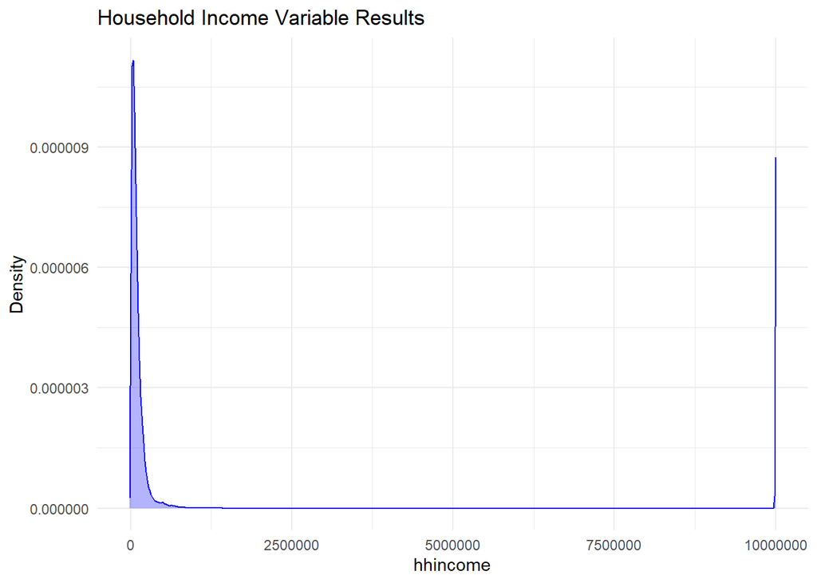

```r
acs_combined %>%
  ggplot(aes(x = hhincome)) +
  geom_density(color = "blue", fill = alpha("blue", 0.3)) +
  theme_minimal() +
  ggtitle("Household Income Variable Results") +
  ylab("Density")
```

Turn the missing/“not in universe” values for the `hhincome` variable into NAs. Rename to the more meaningful “household_income”.

```r
acs_clean <- acs_combined %>%
  mutate(household_income = ifelse(hhincome == 9999999, NA_integer_,
                          hhincome)
  )
```

Look at distribution of `household_income` after adjustment. Some outliers will still exist but bunching around the missing value should not be present.

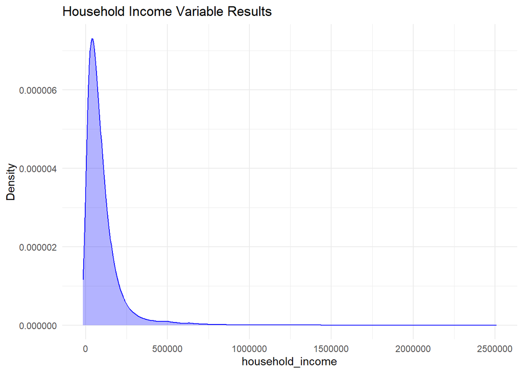

```r
acs_clean %>%
  ggplot(aes(x = household_income)) +
  geom_density(adjust = 5, color = "blue", fill = alpha("blue", 0.3)) +
  theme_minimal() +
  ggtitle("Household Income Variable Results") +
  ylab("Density")
```

Select our group quarters, we want to keep only households including additional households under the 2000 definition. With household income we do not consider group quarters.

```r
acs_clean %>%
  group_by(gq) %>%
  count()
```

```
# A tibble: 5 x 2
# Groups:   gq [5]
  gq                                                n
  <fct>                                         <int>
1 Households under 1970 definition            1280210
2 Additional households under 1990 definition     755
3 Group quarters--Institutions                  77244
4 Other group quarters                          82611
5 Additional households under 2000 definition      45
```

```r
acs_clean <- acs_clean %>%
  filter(gq %in% c("Households under 1970 definition",
                   "Additional households under 1990 definition",
                   "Additional households under 2000 definition"))
```

Check that group quarters fall only into household categories.

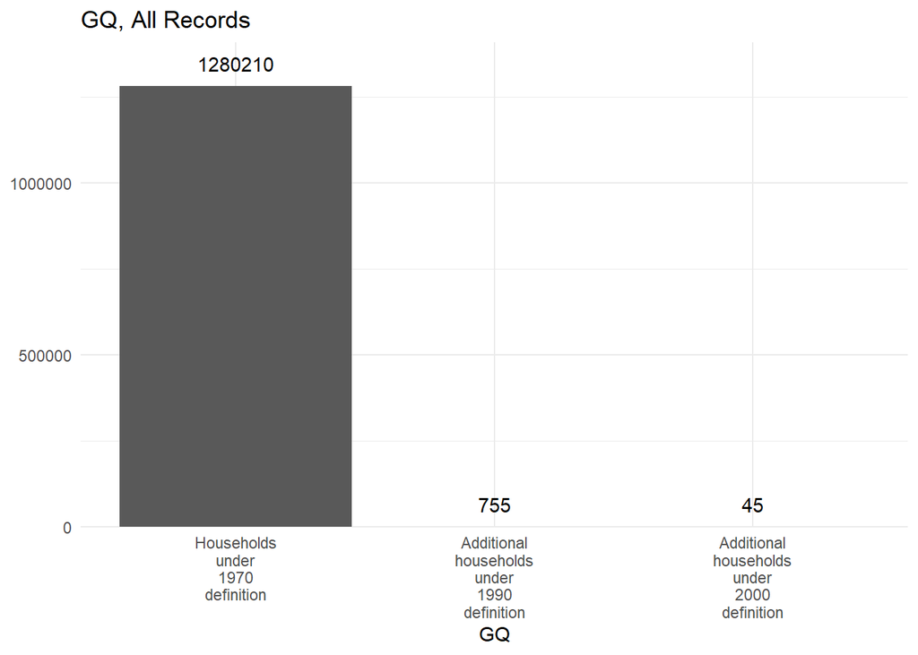

```r
acs_clean %>%
  count(gq) %>%
  ggplot(mapping = aes(x = gq, y = n)) +
  geom_col() +
  theme_minimal() +
  ggtitle("GQ, All Records") +
 geom_text(mapping = aes(label = n), vjust = -1) +
  scale_y_continuous(expand = expansion(mult = c(0, 0.1))) +
  labs(x = "GQ",
       y = NULL) +
  scale_x_discrete(labels = label_wrap(10))
```

## Crosswalk

Read in the PUMA to county crosswalk file. This file is created by the program generate_puma_county_crosswalks.rmd in the geographic-crosswalks folder.

```r
puma_county_crosswalk <- read_csv(
  here::here("geographic-crosswalks", "data", "crosswalk_puma_to_county.csv")
)
```

Create a version with just unique counties for creating a version of the data that matches the UMF county list.

```r
if(params$year < 2022){
  county_list <- puma_county_crosswalk %>%
    filter(crosswalk_period == "pre-2022") %>%
    select(statefip, county) %>%
    filter(statefip != 72) %>%
    unique()

}else{
  county_list <- puma_county_crosswalk %>%
  filter(crosswalk_period == "2022") %>%
  select(statefip, county) %>%
  filter(statefip != 72) %>%
  unique()
}
```

## Merge Crosswalk

Create a variable in the ACS data indicating whether the survey is pre or post-2022. This will be used to join on the correct crosswalk information.

```r
acs_clean <- acs_clean %>%
  mutate(crosswalk_period = ifelse(year < 2022, "pre-2022", "2022"))
```

Check that the assignment worked. All years prior to 2022 should be designated “pre-2022”.

```r
count(acs_clean, crosswalk_period, year)
```

```
# A tibble: 1 x 3
  crosswalk_period  year       n
  <chr>            <int>   <int>
1 pre-2022          2021 1281010
```

Join the cleaned ACS data onto the crosswalk.

```r
acs_crosswalked <- left_join(
  acs_clean,
  puma_county_crosswalk,
  by = c("crosswalk_period", "statefip","puma"),
  relationship = "many-to-many"
)
```

Run an anti_join to see what data does not combine. We keep all counties so there should be no observations resulting from the anti-join.

```r
anti_join(acs_clean,
          puma_county_crosswalk,
          by = c("crosswalk_period", "statefip","puma")
)
```

```
# A tibble: 0 x 112
# i 112 variables: year <int>, sample <fct>, cbserial <dbl>, hhwt <dbl>,
#   adjust <dbl>, statefip <chr>, puma <chr>, gq <fct>, hhincome <dbl>,
#   vacancy <int>, pernum <dbl>, cbpernum <int>, perwt <dbl>, sex <fct>,
#   age <int>, race <fct>, hispan <fct>, educ <int+lbl>, educd <int+lbl>,
#   gradeatt <int+lbl>, gradeattd <int+lbl>, empstat <int>, diffrem <fct>,
#   diffphys <fct>, diffmob <fct>, diffcare <fct>, diffsens <fct>,
#   unique_person_id <chr>, repwt <int+lbl>, repwt1 <dbl>, repwt2 <dbl>, ...
```

```r
rm(acs_clean)
```

Drop any observations with NA for `afact` (i.e. there is no county of interest overlapping this PUMA).

```r
count(acs_crosswalked, is.na(afact))
```

```
# A tibble: 1 x 2
  `is.na(afact)`       n
  <lgl>            <int>
1 FALSE          2827277
```

```r
acs_crosswalked <- acs_crosswalked %>%
  drop_na(afact)
```

Also filter out cases where `afact` is equal to zero. These cases will not be counted in the metric calculation.

```r
count(acs_crosswalked, afact == 0)
```

```
# A tibble: 1 x 2
  `afact == 0`       n
  <lgl>          <int>
1 FALSE        2827277
```

```r
acs_crosswalked <- acs_crosswalked %>%
  filter(afact > 0)
```

Adjust the household weight to account for PUMA-to-county mapping (those where the PUMA is not entirely inside the county).

```r
select(acs_crosswalked, hhwt, repwt1, repwt80, afact)
```

```
# A tibble: 2,827,277 x 4
    hhwt repwt1 repwt80  afact
   <dbl>  <dbl>   <dbl>  <dbl>
 1    42     43      14 0.0965
 2    42     43      14 0.180
 3    42     43      14 0.0921
 4    42     43      14 0.267
 5    42     43      14 0.161
 6    42     43      14 0.122
 7    42     43      14 0.0813
 8    30     32      39 0.171
 9    30     32      39 0.408
10    30     32      39 0.308
# i 2,827,267 more rows
```

```r
acs_crosswalked <- acs_crosswalked %>%
  mutate(hhwt = hhwt * afact,
         across(matches("repwt[0-9]+"), ~.x * afact))

select(acs_crosswalked, hhwt, repwt1, repwt80, afact)
```

```
# A tibble: 2,827,277 x 4
    hhwt repwt1 repwt80  afact
   <dbl>  <dbl>   <dbl>  <dbl>
 1  4.05   4.15    1.35 0.0965
 2  7.56   7.74    2.52 0.180
 3  3.87   3.96    1.29 0.0921
 4 11.2   11.5     3.74 0.267
 5  6.75   6.91    2.25 0.161
 6  5.14   5.27    1.72 0.122
 7  3.41   3.50    1.14 0.0813
 8  5.13   5.47    6.67 0.171
 9 12.2   13.0    15.9  0.408
10  9.24   9.86   12.0  0.308
# i 2,827,267 more rows
```

Apply the Adjust variable to `household_income`. Adjust converts the dollar amounts to the amount that they would have been had they been earned entirely during the calendar year. This is to deal with households being surveyed at different times during the year.

```r
acs_crosswalked <- acs_crosswalked %>%
  mutate(
    household_income = household_income*adjust
  )
```

Confirm there are no missing values remaining in the data set for the household income variable.

```r
acs_crosswalked %>%
  filter(is.na(household_income)) %>%
  count()
```

```
# A tibble: 1 x 1
      n
  <int>
1     0
```

Confirm there are no vacant properties included in the data.

```r
acs_crosswalked %>%
  filter(is.na(vacancy)) %>%
  count()
```

```
# A tibble: 1 x 1
      n
  <int>
1     0
```

## Create income metric: All

Create the income metric.

Objective: calculate the 20th, 50th and 80th quantiles of income by county for all households.

Aggregation should be weighted by HHWT (this is a household level statistic).

### Pre-drop suppressed cells

First, to save time when processing the metric, calculate the effective sample count for each county, defined as the sum of the `afact` variable. This is used to create a cutoff for data quality based on the actual number of survey records being used in the calculation. We will not include counties with less than 30 effective samples.

```r
acs_all <- acs_crosswalked %>%
  group_by(year, sample, crosswalk_period, statefip, county) %>%
  mutate(effective_sample = sum(afact)) %>%
  ungroup()

# calculate the number of statistics after suppressing values
acs_all %>%
  group_by(year, sample, crosswalk_period, statefip, county) %>%
  summarize(
    effective_sample = max(effective_sample)
  ) %>%
  ungroup() %>%
  summarize(
    original_stats = n(),
    unsuppressed_stats = sum(effective_sample >= 30)
  )
```

```
# A tibble: 1 x 2
  original_stats unsuppressed_stats
           <int>              <int>
1           3143               2782
```

Remove records from counties below the size quality cutoff.

```r
acs_all <- acs_all %>%
  filter(effective_sample >= 30)
```

### Calculate metric

Calculate the county-level metrics.

```r
results_all <- acs_all %>%
  group_split(statefip) %>%
  map_dfr(~ calc_income_quantiles(.data = .x, .geo_level = county))
```

Clean up the confidence interval bounds and sort the data.

```r
results_all <- finalize_metric(results_all,
                               .geo_level = county)
```

```r
rm(acs_all)
```

## Add Suppressed Rows to Data

To create the metric we suppressed counties that did not meet the threshold for sample size but we need to include these in the final data. Create an all version of the data that includes counties that were suppressed prior to the survey_mean calculation.

Expand the county_list file so it includes every year in the results. Join the results onto this file and test that the number of records matches the total number of counties we anticipate.

```r
expanded_county_list <- county_list %>%
  left_join(results_all, by = c("statefip", "county"), relationship = "many-to-many") %>%
  mutate(geoid = paste0(statefip, county)) %>%
  expand(year, geoid) %>%
  mutate(statefip = str_sub(geoid, 1, 2),
         county = str_sub(geoid, 3, 5))

results_all_expand <- expanded_county_list %>%
  left_join(results_all, by = c("year", "statefip", "county")) %>%
  filter(!is.na(year))

if(params$year < 2022){
stopifnot(nrow(results_all_expand) == 3143 * n_distinct(results_all_expand$year))
}else{
  stopifnot(nrow(results_all_expand) == 3144 * n_distinct(results_all_expand$year))
}
```

## Data Quality Flags

Add a flag for data quality, this is a numeric variable between 1 and 3 with 1 representing the best quality and 3 representing the worst.

The data quality flag is based on the allocation of the PUMAs that make up a county, which comes from the crosswalk file, and the effective sample size of the county. When the effective sample size is less than 30 all records for that county will be reported as `NA`, including `pctl_income_quality`.

```r
metrics_income_all <- results_all_expand %>%
  mutate(
   pctl_income_20_quality = if_else(
      is.na(pctl_income_20),
      NA_real_,
      geographic_allocation_quality
    ),
    pctl_income_50_quality = if_else(
      is.na(pctl_income_50),
      NA_real_,
      geographic_allocation_quality
    ),
    pctl_income_80_quality = if_else(
      is.na(pctl_income_80),
      NA_real_,
      geographic_allocation_quality
    )
  )
```

### Write out intermediate data

```r
if(isTRUE(bucket_exists(bucket = my_bucket))){
 if (!aws.s3::object_exists(paste0(s3_dir, "/metrics_income_county_all", "_", params$year[1], ".csv"), bucket = my_bucket)){

    # write file to S3
    tmp <- tempfile()
    on.exit(unlink(tmp))
    write_csv(metrics_income_all, file = tmp)

    # put object with an upload progress bar
    put_object(tmp, object = paste0(s3_dir, "/metrics_income_county_all", "_", params$year, ".csv"), bucket = my_bucket,
               show_progress = TRUE, multipart = FALSE)

  }
}
```

```
[1] TRUE
```

If updating a single year the program ends here. To see validation results re-run with selection that all years of intermediate data are available.

```r
if(single_year_update == "Yes"){
  knitr::knit_exit()
}
```